# TP Ecologie Biodiversité Montmaur

Eric Marcon d’après Bastien Mérigot et Guillaume Papuga

2024-03-07

# Data

The classical shape of biodiversity data is a matrix where columns are species and rows are plots. Values are abundances.

## Base R version

Load the data:

```r
montmaur <- read.csv2("data/species.csv")
```

Interactive version:

```r
montmaur <- read.table(file.choose(), sep=";", dec=",", header=T)
# Edit the data
montmaur <- edit(montmaur)
```

Editing the data interactively is a bad practice because it is not reproducible. Do rather edit the original file.

Explore the data:

```r
head(montmaur)
str(montmaur)
summary(montmaur)
```

Map the plots:

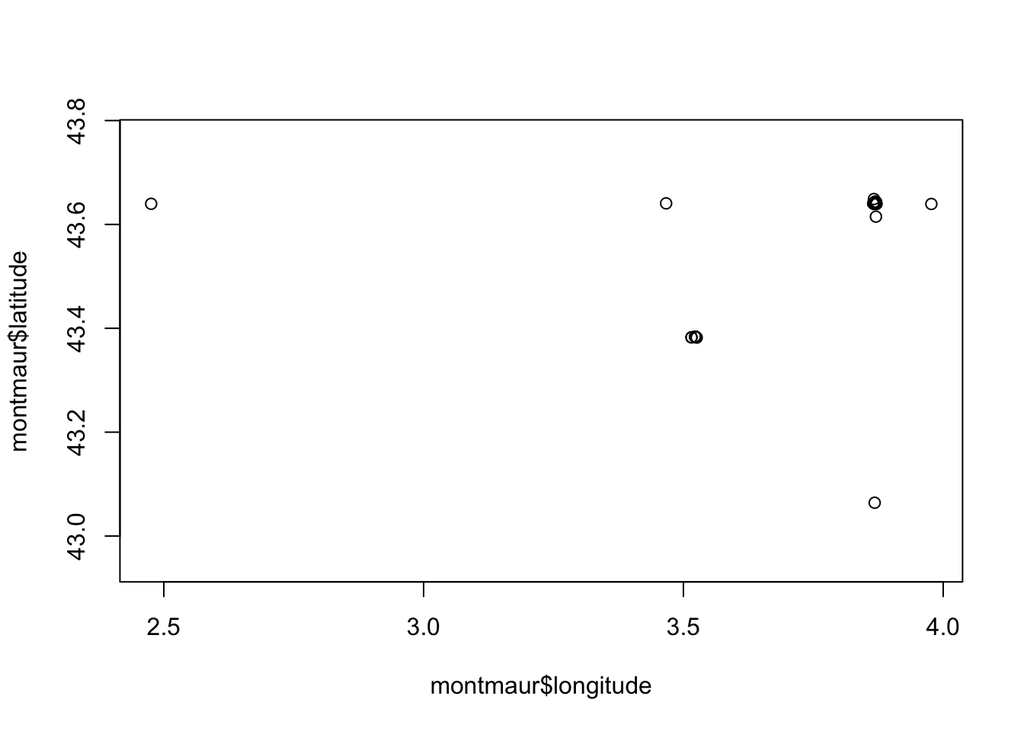

```r
# Force the aspect ratio
plot(x = montmaur$longitude, y = montmaur$latitude, asp = 1)
```

Avoid repeating `montmaur$`:

- With `attach()`: bad practice. See `?attach`.

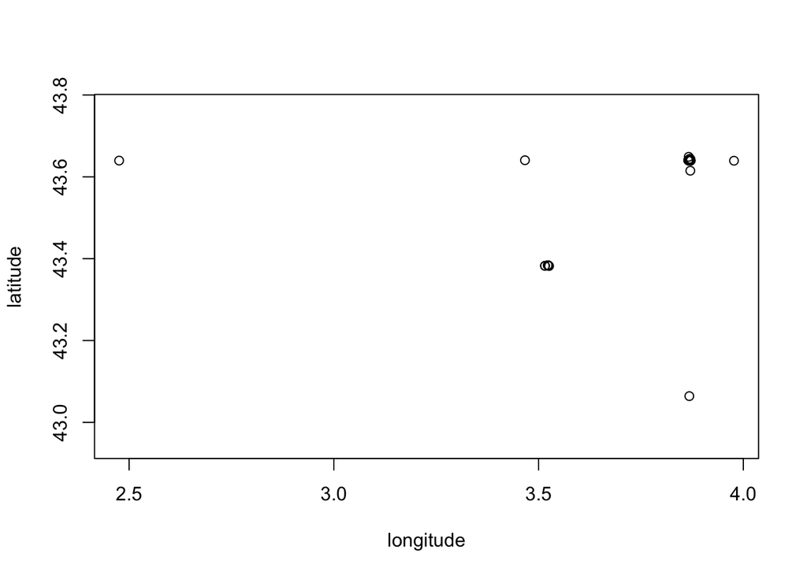

```r
attach(montmaur)
plot(x = longitude, y = latitude, asp = 1)
```

```r
# Don't forget to detach after use!
detach(montmaur)
```

- With `with()`.

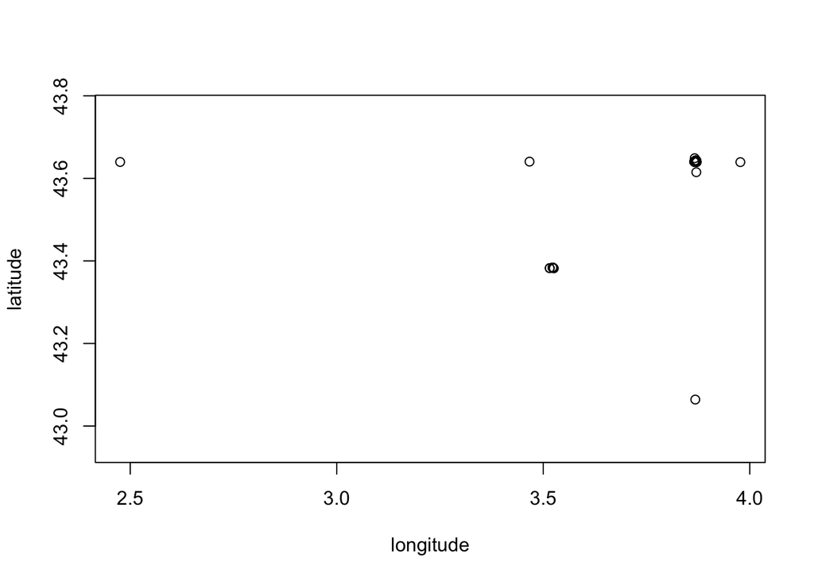

```r
with(montmaur,
  # Indent the code
  plot(x = longitude, y = latitude, asp = 1)
  # Close the bracket
)
```

Are some plots empty?

```r
# The first 10 columns contain plot data, the others, the species abundances
min(rowSums(montmaur[, -(1:10)]))
```

```
## [1] 8
```

Are some species missing?

```r
# The first 10 columns contain plot data, the others, the species abundances
which(colSums(montmaur[, -(1:10)]) == 0)
```

```
## ARUITA CENPAN CEPLEU CIRMON CLINEP CREBUR FRAORN NARASS ONONAT PANMIL  RUBSP
##      4     16     17     19     24     27     38     56     58     59     78
## SCAMAR SCOHIS SONTER TORARV VULBRO
##     83     84     91     95    102
```

```r
# Numbers are those of the columns. They are named.
```

Create a dataframe with species abundances only, and eliminate absent species

```r
montmaur_sp <- montmaur[, -(1:10)][, which(colSums(montmaur[, -(1:10)]) > 0)]
# Add the plot names
rownames(montmaur_sp) <- montmaur$code_rel
```

Make dataframes for the north and south face only:

```r
montmaur_sp_n <- montmaur_sp[montmaur$versant == "N", ]
montmaur_sp_s <- montmaur_sp[montmaur$versant == "S", ]
```

Graphical representation of the data table:

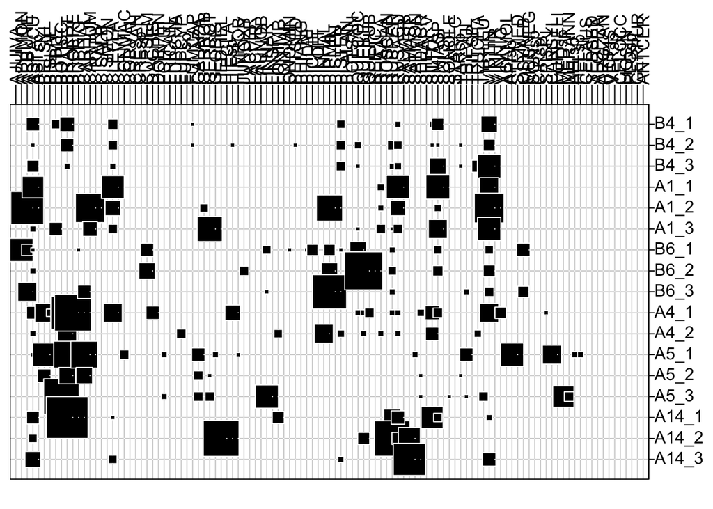

```r
library("ade4")
table.value(montmaur_sp_n, clegend=0)
```

## Tidyverse

Read the data.

```r
library("tidyverse")
montmaur <- read_csv2("data/species.csv")
```

Make a pipeline to select rows and columns:

```r
montmaur %>%
  # Filter the north face
  filter(versant == "N") %>%
  # Select species columns
  select(!(Groupe:rec_tot)) %>%
  # Eliminate absent species
  select(where(~ sum(.x) != 0))
```

```
## # A tibble: 17 × 64
##    APHMON ARBUNE ASPACU BELSYL BISLAE BITBIT BOTISC BRARET BROERE BUPRIG CARHAL
##     <dbl>  <dbl>  <dbl>  <dbl>  <dbl>  <dbl>  <dbl>  <dbl>  <dbl>  <dbl>  <dbl>
##  1      0      0     10      0      0      5      0     12      0      0      0
##  2      0      0      1      0      0      0      0     10      0      0      0
##  3      0      0      8      0      0      0      0      2      0      0      0
##  4      0      0     26      0      0      0      0      0      0      0      0
##  5      0     60      0      0      0      0      0      0      0      0      0
##  6      0      0      2      0      0     10      0      0      0      0      0
##  7     30      7      1      0      0      0      0      0      0      1      0
##  8      0      0      2      0      0      0      0      0      0      0      0
##  9      0     20      0      0      0      0      0      0      0      0     10
## 10      0      0      9     20      3      0      0     60     75      0      0
## 11      0      0      2      0      0      0      0     20      0      0      0
## 12      0      0      1     30      0      0      0     40      0      0     40
## 13      0      0      0     10      0      0      0     15      0      0     15
## 14      0      0      0      0      0      0     70      0      0      0      0
## 15      0      0      9      0      0      0      0     97      0      0      0
## 16      0      0      4      0      0      0      0      0      0      0      0
## 17      0      0     14      0      0      0      0      0      0      0      0
## # ℹ 53 more variables: CARHUM <dbl>, CISMON <dbl>, CLEFLA <dbl>, CONMAC <dbl>,
## #   CUPSEM <dbl>, DACHIS <dbl>, ECHVUL <dbl>, EUPCYP <dbl>, FUMCAP <dbl>,
## #   GALAPA <dbl>, GERROB <dbl>, GERROT <dbl>, GLOBIS <dbl>, HEDHEL <dbl>,
## #   HIEsp <dbl>, HIMROB <dbl>, JUNOXY <dbl>, LINNAR <dbl>, LONIMP <dbl>,
## #   ONOMIN <dbl>, PETSED <dbl>, PHILAT <dbl>, PICHIE <dbl>, PINHAL <dbl>,
## #   PIPMIL <dbl>, PISTER <dbl>, QUECOC <dbl>, QUEILE <dbl>, QUEPUB <dbl>,
## #   RHAALA <dbl>, RUBPER <dbl>, RUSACU <dbl>, SAMASP <dbl>, SATMON <dbl>, …
```

Learn to make beautiful plots with **ggplot2** (Wickham et al. 2024) at the [R graph gallery](https://r-graph-gallery.com/).

# Rank-abundance diagram

Course: Marcon (2018), section [2.4](https://ericmarcon.github.io/MesuresBioDiv2/chap-Outils.html#distribution-de-labondance-des-esp%C3%A8ces-sad).

## Abundances: species cover

Compute the probability for an area to be covered by each species.

```r
# Sum the species cover
montmaur_cover <- colSums(montmaur_sp)
# Normalise
montmaur_cover <- montmaur_cover / sum(montmaur_cover)
```

Try to fit the distribution to a well-known one.

```r
library("vegan")
radfit(montmaur_cover)
```

```
##
## RAD models, family poisson
## No. of species 111, total abundance 1
##
##            par1     par2    par3   Deviance AIC      BIC
## Null                               0.414910      Inf      Inf
## Preemption    0.1                  0.358534      Inf      Inf
## Lognormal  -5.8517   1.5479        0.040585      Inf      Inf
## Zipf        0.19286 -1.0098        0.182829      Inf      Inf
## Mandelbrot  0.38234 -1.2053      1 0.113622      Inf      Inf
```

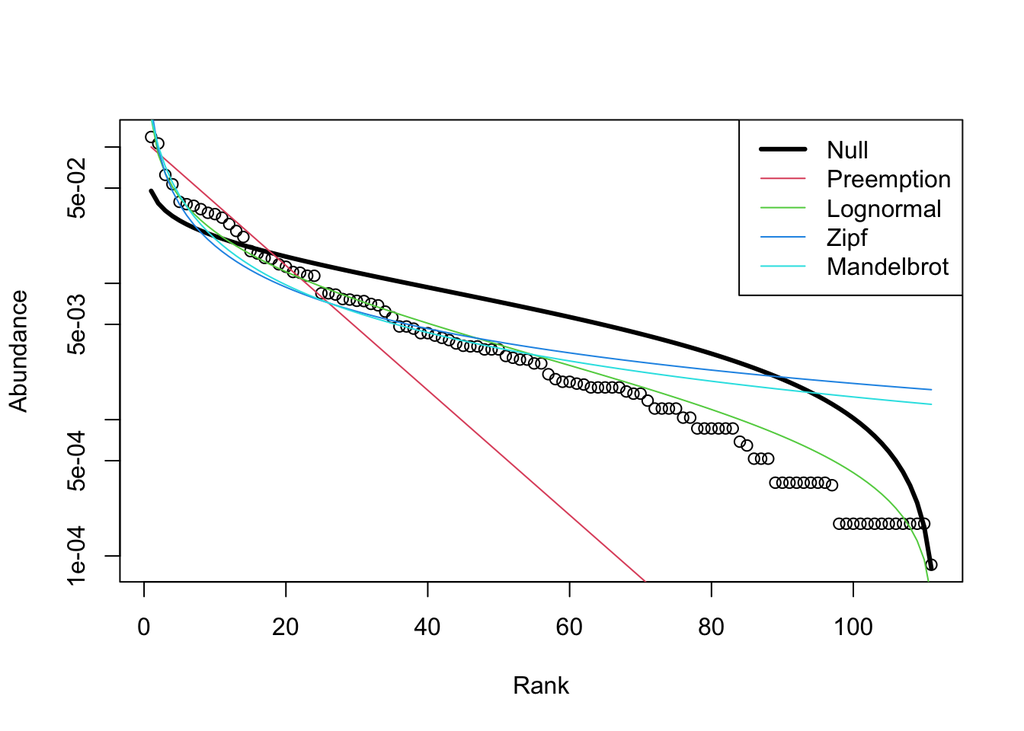

```r
plot(radfit(montmaur_cover))
```

## Occurrence

Count the number of plots where each species is observed.

```r
# Species occurrences
montmaur_occurrence <- specnumber(montmaur_sp, MARGIN = 2)
radfit(montmaur_occurrence)
```

```
##
## RAD models, family poisson
## No. of species 111, total abundance 674
##
##            par1      par2     par3    Deviance AIC      BIC
## Null                                  109.8751 451.0722 451.0722
## Preemption  0.041921                   87.9967 431.1939 433.9034
## Lognormal   1.1247    1.1839           32.8840 378.0812 383.5002
## Zipf        0.1303   -0.83616          70.6550 415.8521 421.2712
## Mandelbrot  2.608    -1.5751   8.4048   8.8447 356.0419 364.1705
```

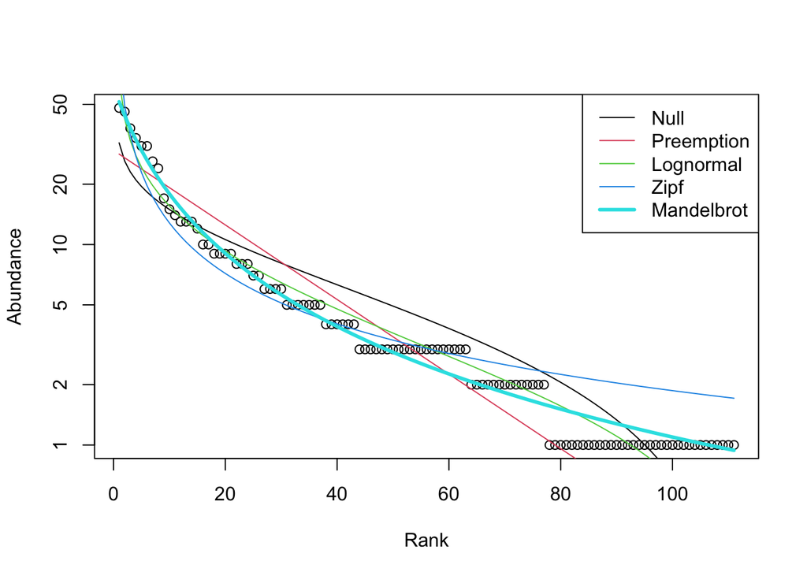

```r
plot(radfit(montmaur_occurrence))
```

## Compare abundance and occurence

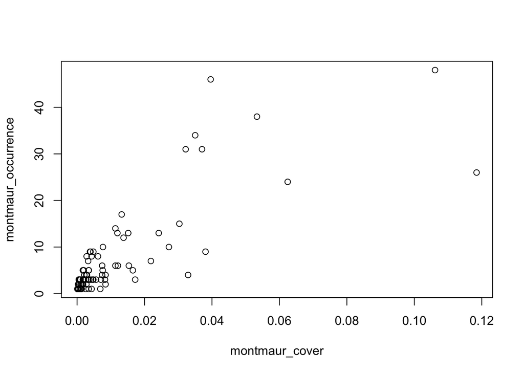

```r
plot(x = montmaur_cover, y = montmaur_occurrence)
```

# Taxonomic Diversity

Course: Marcon (2018), chapters [3](https://ericmarcon.github.io/MesuresBioDiv2/chap-MesuresNeutres.html) and [4](https://ericmarcon.github.io/MesuresBioDiv2/entropie.html).

## Richness

Count the number of species per plot.

```r
# Specific richness S
(plot_richness <- specnumber(montmaur_sp, MARGIN = 1))
```

```
##   B9_1   B9_2   B9_3   B4_1   B4_2   B4_3   A1_1   A1_2   A1_3   B6_1   B6_2
##      8     11      8     10     14     12      8      9     11     16      9
##   B6_3   A7_1   A7_2   A7_3  A12_1  A12_2  A12_3  A10_1  A10_2  A10_3   B7_1
##      8     11     12      8      9      8     12      8      8      9     17
##   B7_2   B7_3   A8_1   A8_2   A8_3  B10_1  B10_2  B10_3   A4_1   A4_2  B11_1
##     13     16     10     11      8     12     13     12     19     11     12
##  B11_2  B11_3   A9_1   A9_2   A9_3   A5_1   A5_2   A5_3  B13_1  B13_2  B13_3
##     16     10     14     14     12     15      7     12      8     14     12
## B10b_1 B10b_2 B10b_3  A14_1  A14_2  A14_3  A13_1  A13_2  A13_3   A2_1   A2_2
##      9     11     11      9      6      5     10      8      6     12     13
##   A2_3   B8_1   B8_2   B8_3   A6_1   A6_2   A6_3  A11_1  A11_2  A11_3
##     15      4      4      3      9      7     10     10      5     10
```

## Accumulation curves

The level of diversity depends on the sampling effort.

### Assess diversity at a sampling level

Course: Marcon (2018), sections [2.1](https://ericmarcon.github.io/MesuresBioDiv2/chap-Outils.html#courbes-daccumulation) and 2.2.

Accumulation curves can be built by package **vegan** (Oksanen et al. 2022).

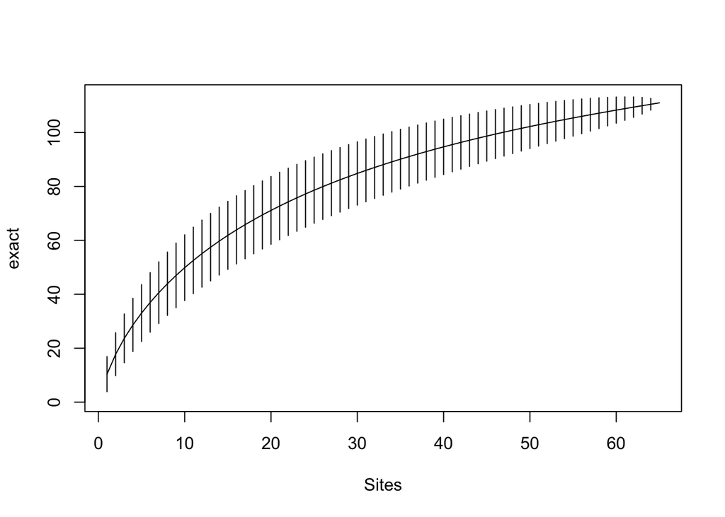

```r
library("vegan")
sac <- specaccum(montmaur_sp)
plot(sac)
```

```r
sac_n <- specaccum(montmaur_sp_n)
sac_s <- specaccum(montmaur_sp_s)
```

The number of species is in the `$richness` item of the `specaccum` object, which is a list.

```r
sac$richness
```

```
##  [1]  10.36923  17.76250  23.64718  28.64115  33.03678  36.99077  40.59721
##  [8]  43.91813  46.99761  49.86876  52.55753  55.08492  57.46829  59.72227
## [15]  61.85930  63.89010  65.82396  67.66897  69.43226  71.12008  72.73801
## [22]  74.29101  75.78350  77.21947  78.60252  79.93590  81.22257  82.46523
## [29]  83.66637  84.82824  85.95295  87.04244  88.09851  89.12282  90.11694
## [36]  91.08233  92.02036  92.93230  93.81937  94.68271  95.52340  96.34246
## [43]  97.14087  97.91954  98.67936  99.42118 100.14578 100.85394 101.54641
## [50] 102.22387 102.88703 103.53653 104.17301 104.79707 105.40932 106.01031
## [57] 106.60061 107.18076 107.75128 108.31268 108.86547 109.41012 109.94712
## [64] 110.47692 111.00000
```

```r
# Total richness is also
sum(colSums(montmaur_sp) != 0)
```

```
## [1] 111
```

Plot north and south SAC:

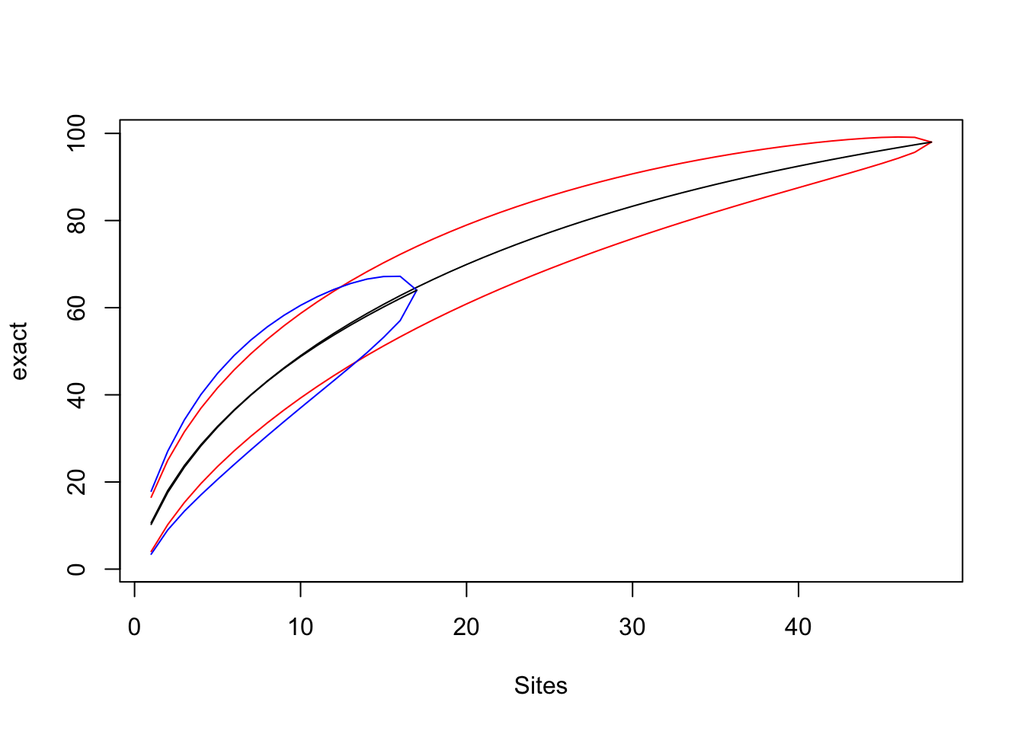

```r
plot(sac_s, ci.type = "line", ci.col = "red")
plot(sac_n, ci.type = "line", ci.col = "blue", add = TRUE)
```

### Rarefaction to compare diversity

Course: Marcon (2018), chapter [21](https://ericmarcon.github.io/MesuresBioDiv2/chap-Accumulation.html#chap-Accumulation).

Rarefy the data to the smallest sample size.

```r
# Find the smallest number of plots
rarefied_n <- min(nrow(montmaur_sp_n), nrow(montmaur_sp_s))
# Estimate and estimator sd
# Ratified richness at n=rarefied_n plots
sac_n$richness[rarefied_n]
```

```
## [1] 64
```

```r
sac_n$sd[rarefied_n]
```

```
## [1] 0
```

```r
sac_s$richness[rarefied_n]
```

```
## [1] 64.68061
```

```r
sac_s$sd[rarefied_n]
```

```
## [1] 4.687229
```

Compare the diversity of north and south face.

## Extrapolation

Extrapolation is possible, up to twice the sample size without too much uncertainty. See the **iNext** package (Hsieh, Ma, and Chao 2016) for the [framework](https://cran.r-project.org/web/packages/iNEXT/vignettes/Introduction.pdf).

```r
library("entropart")
Richness(montmaur_occurrence, Level = 2 * sum(montmaur_occurrence))
```

```
##     Best
## 129.1708
```

Pot the accumulation curve:

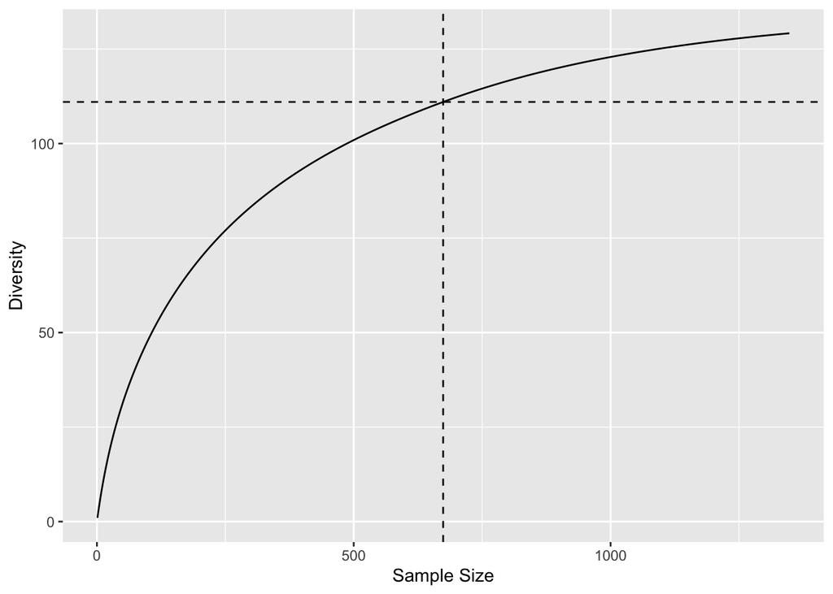

```r
autoplot(
  DivAC(
    montmaur_occurrence,
    q = 0,
    n.seq = 1:(2 * sum(montmaur_occurrence))
  )
)
```

## Asymptotic richness

Course: Marcon (2018), sections [2.2](https://ericmarcon.github.io/MesuresBioDiv2/chap-Outils.html#diversit%C3%A9-asymptotique) and [3.1](https://ericmarcon.github.io/MesuresBioDiv2/chap-MesuresNeutres.html#sec-Richesse)

Requires estimators based on the number of individuals or on the number of occurrences, available in package **entropart** (Marcon and Herault 2023).

```r
Richness(montmaur_occurrence, Correction = "Chao1")
```

```
##    Chao1
## 152.2245
```

## Shannon, Simpson, entropy

Richness minus one species, Shannon (1948) and Simpson (1949) indices measure entropy, i.e. an amount of information.

In a community:

- The *probability* $p_s$ of a species is the probability for an individual to belong to it. When individuals are not well-defined, another definition must be chosen: with abundance-dominance data, it is the proportion of total coverage occupied by the species.
- The *rarity* of a species is the reciprocal of its probability, i.e. $1/p_s$.
- The information brought by the species is:
  - $(1-p_s)/p_s$ for richness (full line)
  - the logarithm of rarity for Shannon ($\ln(1/p_s)$) (long dashes),
  - $1-p_s$ for Simpson (sort dashes).

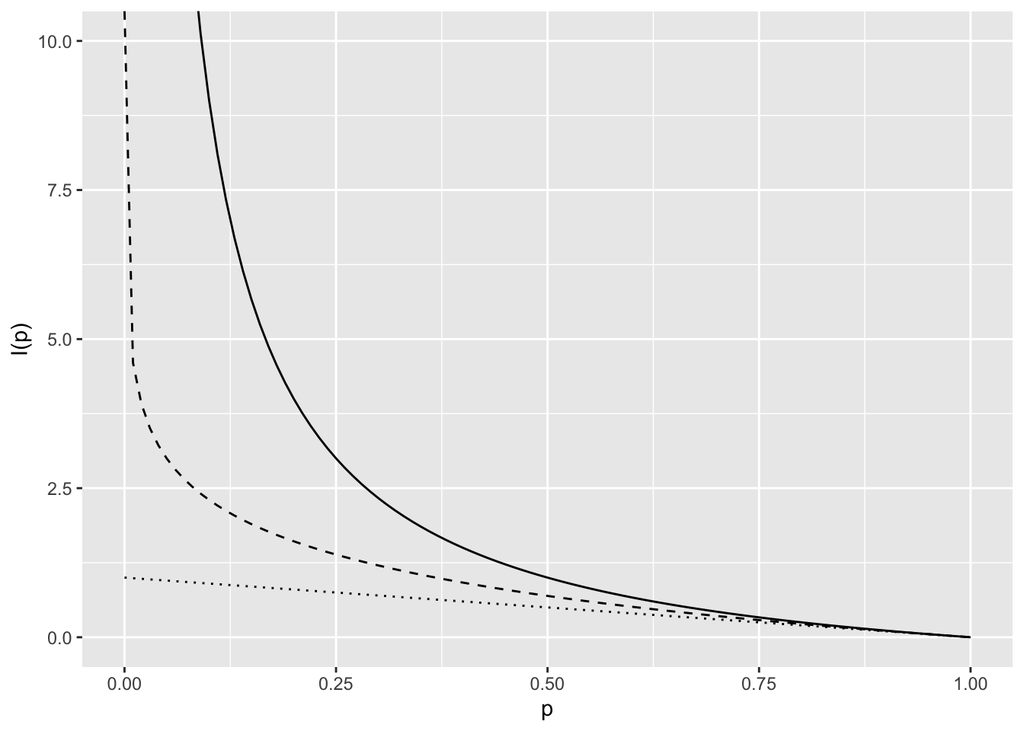

```r
I0 <- function(p) (1 - p) / p
I1 <- function(p) -log(p)
I2 <- function(p) 1 - p
ggplot(data.frame(x=c(0, 1)), aes(x)) +
    stat_function(fun = I0) +
    stat_function(fun = I1, lty = 2) +
    stat_function(fun = I2, lty = 3) +
    coord_cartesian(ylim = c(0, 10)) +
    labs(x = "p", y = "I(p)")
```

- The entropy of the community is the average information brought by its species.

The information function gives more (richness) or less (Simpson) weight to rare species.

```r
# Shannon
Shannon(montmaur_occurrence, Correction = "None")
```

```
##     None
## 4.035835
```

```r
# Asymptotic
Shannon(montmaur_occurrence)
```

```
##  UnveilJ
## 4.202356
```

```r
# Cover data
Shannon(montmaur_cover)
```

```
##     None
## 3.638766
```

Simpson’s entropy is the probability for two individuals to belong to different species.

```r
# Simpson
Simpson(montmaur_occurrence, Correction = "None")
```

```
##      None
## 0.9712642
```

```r
# Asymptotic
Simpson(montmaur_occurrence)
```

```
##     Lande
## 0.9727074
```

```r
# Cover data
Simpson(montmaur_cover)
```

```
##    None
## 0.95459
```

The generalized entropy extends this approach. The deformed logarithm function of order $q$ is $\ln_q(x) = \frac{x^{1-q} - 1}{1 - q}$.

- the natural logarithm for $q=1$ : $\ln_1(x) = \ln(x)$.
- a more concave function for $q > 1$ : $\ln_2(x) = 1 - 1/x$.
- a less concave function for $q < 1$ : $\ln_0(x) = x - 1$.

Then:

- entropy of order q is the average deformed logarithm (of order q) of rarity: $^{q}H = \sum_s {\ln_q(1/p_s)}$.
- entropy of order 0 is richness minus 1.
- entropy of order 1 is Shannon’s entropy.
- entropy of order 2 is Simson’s entropy.
- the greater $q$, the less importance is given to rare species.

## Diversity

Diversity sensu stricto is the number of equiprobable species that would yield the same entropy as the data. It is called a Hill (1973) number or a number equivalent or the effective number of species (Jost 2006).

It is the exponential of Shannon’s entropy and the reciprocal of Simpson’s similarity.

```r
# Shannon
Diversity(montmaur_cover, q = 1)
```

```
##     None
## 38.04485
```

```r
exp(Shannon(montmaur_cover))
```

```
##     None
## 38.04485
```

```r
# Simpson
Diversity(montmaur_cover, q = 2)
```

```
##     None
## 22.02158
```

```r
1 / (1 - Simpson(montmaur_cover))
```

```
##     None
## 22.02158
```

In general, diversity of order $q$ is the deformed exponential of entropy of order $q$.

```r
# Simpson
expq(Simpson(montmaur_cover), q = 2)
```

```
##     None
## 22.02158
```

```r
# From diversity to entropy
lnq(Diversity(montmaur_cover, q = 2), q = 2)
```

```
##    None
## 0.95459
```

## Diversity profile

Plot diversity with respect to its order.

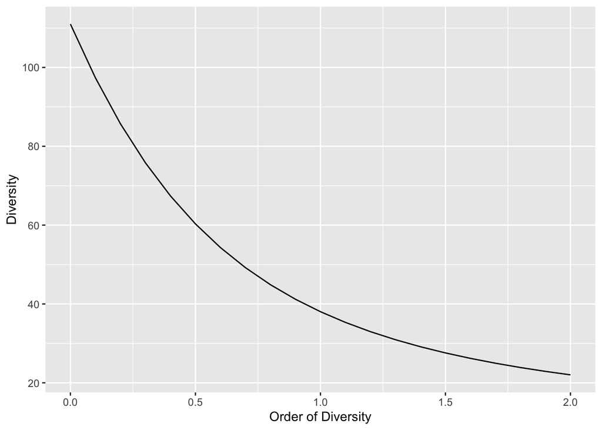

```r
autoplot(CommunityProfile(Diversity, montmaur_cover))
```

# Functional diversity

```r
traits <- read.csv2("data/traits.csv")
# chlorophyll
trait_chlorophyll <- aggregate(chlorophylle ~ code_espece, data = traits, FUN = mean)
# Biological type
trait_type <- aggregate(type_biologique ~ code_espece, data = traits, FUN = unique)
# Trait table
traits <- cbind(trait_chlorophyll, trait_type)
# Delete doubled column and keep observed species only
traits <- traits[traits$code_espece %in% colnames(montmaur_sp), -3]
head(traits)
```

```
##   code_espece chlorophylle type_biologique
## 1      ACAMOL     50.70000 hemicryptophyte
## 3      BELSYL     38.60000          vivace
## 4      BROERE     37.10000 hemicryptophyte
## 5      CELAUS     52.24667   phanerophyte
## 6      CLEFLA     53.56667      chamephyte
## 7      CRESAN     23.03333      therophyte
```

## Community weighted mean

Course: Marcon (2018), section [7.7](https://ericmarcon.github.io/MesuresBioDiv2/mesures-particuli%C3%A8res.html#diversit%C3%A9-et-moyenne).

Defined by Garnier et al. (2004). CWM is a mean, not a diversity.

```r
species_weights <- colSums(montmaur_sp)[colnames(montmaur_sp) %in% traits$code_espece]
mean(traits$chlorophylle, w = species_weights)
```

```
## [1] 40.57018
```

```r
# By type (unweighted)
aggregate(chlorophylle ~ type_biologique, data = traits, FUN = mean)
```

```
##      type_biologique chlorophylle
## 1         chamephyte     43.54817
## 2           epiphyte     54.96667
## 3           geophyte     14.16667
## 4    hemicryptophyte     44.28879
## 5  macrophanerophyte     38.95714
## 6  microphanerophyte     46.86667
## 7   nanophanerophyte     38.00833
## 8       phanerophyte     54.86667
## 9      phanerophyte      49.19944
## 10        therophyte     22.21111
## 11            vivace     38.60000
```

For intensive use, see `BAT::cwm()`.

## Functional Distance

Course: Marcon (2018), chapter [6](https://ericmarcon.github.io/MesuresBioDiv2/chap-cadrephyfonc.html#chap-cadrephyfonc).

Functional distance between species following Gower (1971).

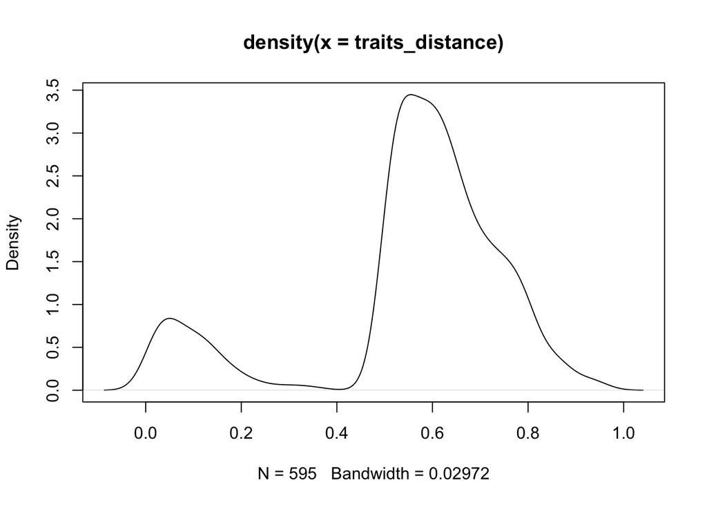

```r
library("FD")
# Distances based on traits, not including species names.
traits_distance <- gowdis(traits[, -1])
plot(density(traits_distance))
```

## Quadratic entropy

Course: Marcon (2018), section [7.6](https://ericmarcon.github.io/MesuresBioDiv2/mesures-particuli%C3%A8res.html#sec-Rao).

Rao’s entropy (aka quadratic entropy) is the average distance between two individuals.

```r
library("adiv")
montmaur_qe <- QE(
  comm = montmaur_sp[, traits$code_espece],
  dis = traits_distance
)
```

## Hierarchical classification

Functional classification of species (complementarity-redundancy) with CAH (mean linkage) based on Gower distances:

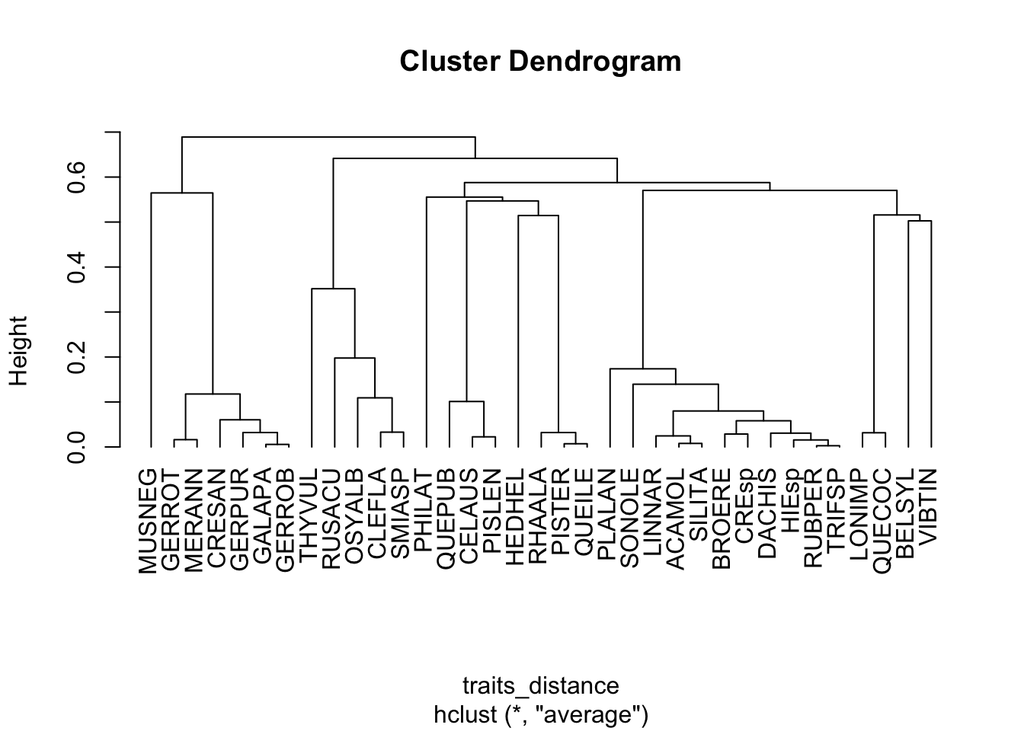

```r
# Restore the species names
attr(traits_distance, "Labels") <- traits$code_espece
species_fhc <- hclust(traits_distance, method = "average")
plot(species_fhc, hang = -1)
```

# Phylogenetic diversity

Course: Marcon (2018), chapter [8](https://ericmarcon.github.io/MesuresBioDiv2/chap-Phyloentropie.html#chap-Phyloentropie).

Defined to assess the dissimilarities between species summarized in a dendrogram. We’ll use the functional dendrogram above as an exercice, even though it is not a good approach to measure functional diversity.

The dendrogram is cut into slices at each node height. Entropy is calculated in each slice and averaged along the tree: it is the average information along time (if the dendrogram represents evolutionary times) and diversity is its exponential.

PD (Faith 1992), aka FD (Petchey and Gaston 2006) is the total length of branches, i.e. richness.

```r
# Subset the data: keep species of the tree only
montmaur_reduced <- montmaur_occurrence[
  names(montmaur_occurrence) %in% species_fhc$labels
]
# FD
PDFD(as.ProbaVector(montmaur_reduced), species_fhc)
```

```
##     None
## 7.367722
```

Entropy of order 2 is the average distance between two individuals, i.e. Rao’s entropy.

```r
# Asymptotic Rao's entropy in a normalized tree
PhyloEntropy(montmaur_reduced, q = 2, Tree = species_fhc, Normalize = TRUE)
```

```
## $Distribution
## [1] "-"
##
## $Function
## [1] "PhyloEntropy"
##
## $Tree
## [1] "species_fhc"
##
## $Normalized
## [1] TRUE
##
## $Cuts
## 0.00270004909180177 0.00564555719194892 0.00711831124202256 0.00785468826705948
##           0.9399818           0.9391614           0.9377729           0.9348890
##  0.0155866470299461    0.01620029455081  0.0224840451644575  0.0245459008345607
##           0.9343772           0.9317196           0.9313123           0.9308529
##  0.0287187039764359   0.030674194076256  0.0315414825724104  0.0320324005891016
##           0.9299035           0.9296322           0.9280452           0.9263362
##  0.0328915071183112  0.0581921944035346  0.0603829160530192  0.0799664539355261
##           0.9223485           0.9063705           0.9012435           0.9002669
##   0.101043200785469   0.109174030436917   0.117697594501718   0.139456171930399
##           0.8871237           0.8865133           0.8837056           0.8818746
##   0.173703976435935   0.197657911962036   0.351756566028473    0.50262991794656
##           0.8733295           0.8711899           0.8379867           0.8264849
##   0.514482081492391   0.515770741286205    0.54694812632957   0.555468476050214
##           0.8225788           0.8187812           0.8019359           0.7930115
##   0.564719358533791   0.570307987299887    0.58773980468476   0.641532754294008
##           0.7789467           0.7773589           0.6923219           0.5242929
##   0.689065834360253
##           0.1574760
##
## $Corrections
## 0.00270004909180177 0.00564555719194892 0.00711831124202256 0.00785468826705948
##           "UnveilJ"           "UnveilJ"           "UnveilJ"           "UnveilJ"
##  0.0155866470299461    0.01620029455081  0.0224840451644575  0.0245459008345607
##           "UnveilJ"           "UnveilJ"           "UnveilJ"           "UnveilJ"
##  0.0287187039764359   0.030674194076256  0.0315414825724104  0.0320324005891016
##           "UnveilJ"           "UnveilJ"           "UnveilJ"           "UnveilJ"
##  0.0328915071183112  0.0581921944035346  0.0603829160530192  0.0799664539355261
```

[output cut: 11 more lines]

```
##
## $Total
## [1] 0.7725398
##
## $Type
## [1] "alpha or gamma"
##
## $Order
## [1] 2
##
## $Correction
## [1] "Best"
##
## attr(,"class")
## [1] "PhyloEntropy" "PhyloValue"
```

Diversity is its deformed exponential of order 2, i.e. 1/(1 - entropy).

```r
PhyloDiversity(montmaur_reduced, q = 2, Tree = species_fhc, Normalize = TRUE)$Total
```

```
## [1] 4.396374
```

# Beta diversity

Course: Marcon (2018), chapter [10](https://ericmarcon.github.io/MesuresBioDiv2/sec-betaCadre.html).

## Partitioning

Course: Marcon (2018), chapter [12](https://ericmarcon.github.io/MesuresBioDiv2/chap-DedompHCDT.html#chap-DedompHCDT).

Défined by Whittaker (1960). Multiplicative partitioning:

```r
# Total number of species
richness_gamma <- sum(colSums(montmaur_sp) > 0)
# Average number of species per plot
richness_plot <- apply(montmaur_sp, MARGIN = 1, FUN = function(plot) sum(plot > 0))
richness_alpha <- mean(richness_plot)
richness_beta <- richness_gamma / richness_alpha
```

$\beta$ diversity is the effective number of plots, i.e. the number of equally-weighted plots that would yield the same diversity as the data.

Additive partitioning (Lande 1996):

```r
richness_gamma - richness_alpha
```

```
## [1] 100.6308
```

Additive partitioning is valid for entropy.

## Differentiation

Course: Marcon (2018), chapter [11](https://ericmarcon.github.io/MesuresBioDiv2/chap-BetaPaires.html#chap-BetaPaires).

How different are two plots?

Jaccard dissimilarity is based on occurrence data.

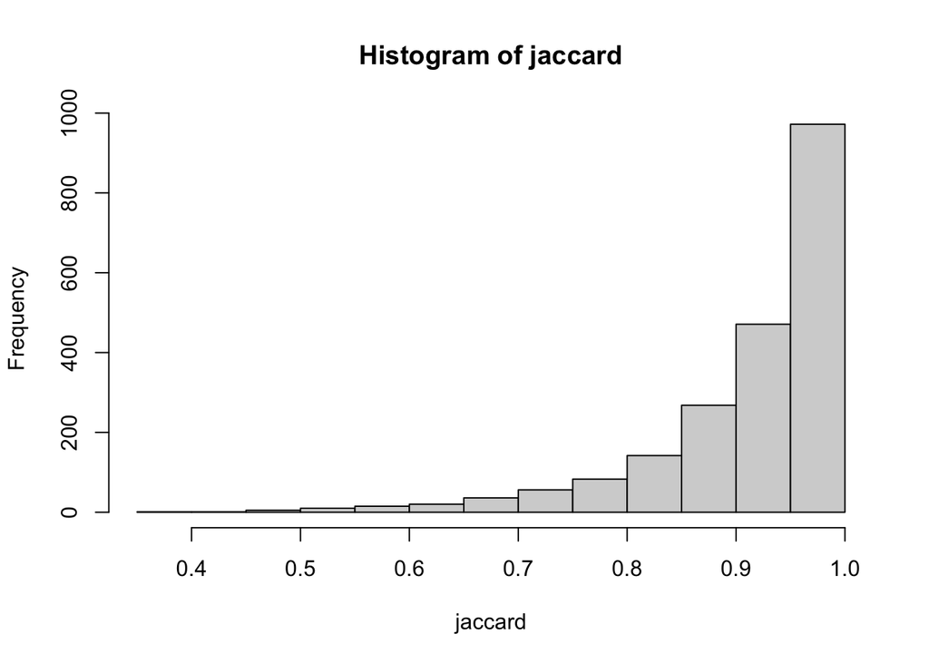

```r
library("vegan")
jaccard <-vegdist(montmaur_sp, method = "jaccard")
hist(jaccard)
```

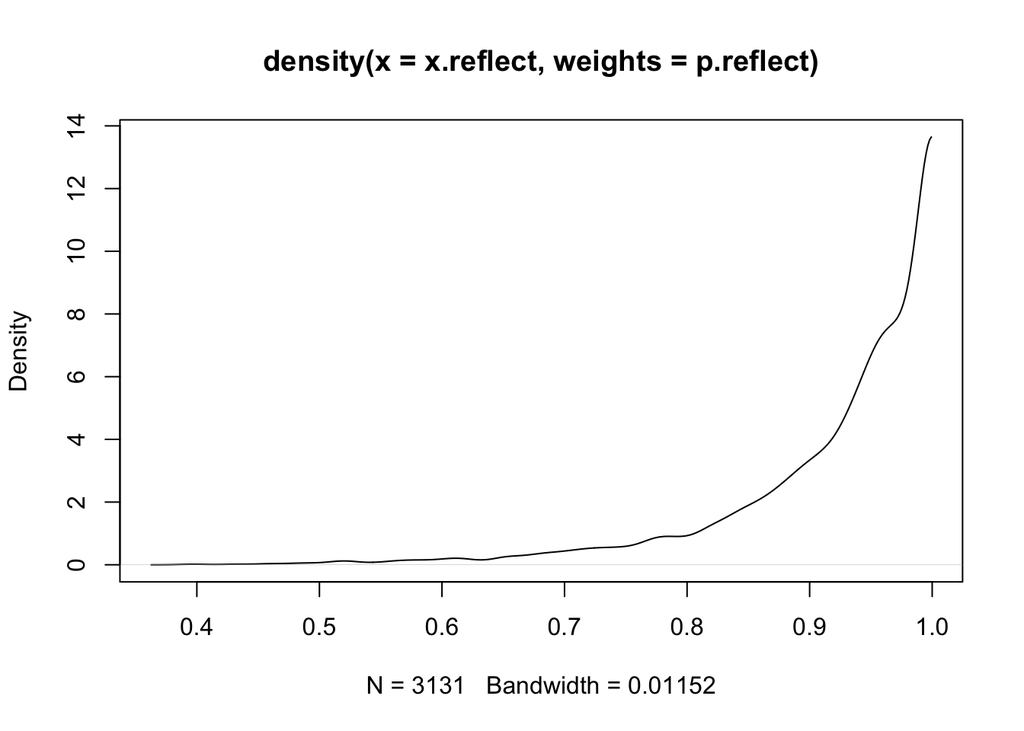

```r
# Smooth the histogram, no values above 1
library("GoFKernel")
plot(density.reflected(jaccard, upper = 1))
```

Bray-Curtis dissimilarity is based on abundance data.

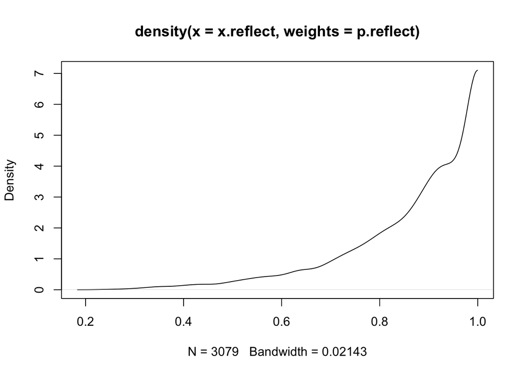

```r
bray <-vegdist(montmaur_sp, method = "bray")
plot(density.reflected(bray, upper = 1))
```

## Conciliation

The figure of plots after a non-scaled, centred PCA shows the contribution of each plot to Simpson’s $\beta$ entropy (partitioning). The distance between plots is Simpson’s $\beta$ entropy between them (differentiation).

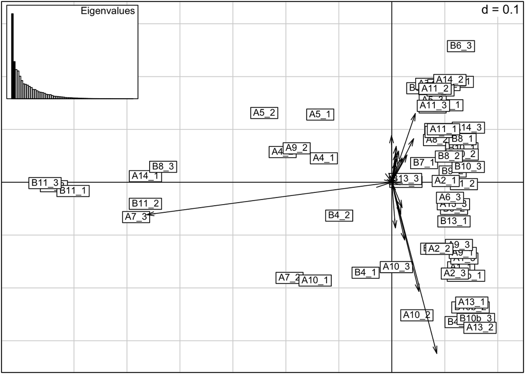

```r
montmaur_pca <- dudi.pca(
  montmaur_sp/rowSums(montmaur_sp),
  scannf = FALSE,
  nf = 2,
  center = TRUE,
  scale = FALSE
)
scatter(montmaur_pca, clab.col = 0)
```

# References

Faith, Daniel P. 1992. “Conservation Evaluation and Phylogenetic Diversity.” *Biological Conservation* 61 (1): 1–10. https://doi.org/10.1016/0006-3207(92)91201-3.

Garnier, Eric, Jacques Cortez, Georges Billès, Marie-Laure Navas, Catherine Roumet, Max Debussche, Gérard Laurent, et al. 2004. “Plant Functional Markers Capture Ecosystem Properties During Secondary Succession.” *Ecology* 85 (9): 2630–37. https://doi.org/10.1890/03-0799.

Gower, J. C. 1971. “A General Coefficient of Similarity and Some of Its Properties.” *Biometrics* 27 (4): 857–71. https://doi.org/10.2307/2528823.

Hill, M. O. 1973. “Diversity and Evenness: A Unifying Notation and Its Consequences.” *Ecology* 54 (2): 427–32. https://doi.org/10.2307/1934352.

Hsieh, T. C., K. H. Ma, and Anne Chao. 2016. “iNEXT: An R Package for Interpolation and Extrapolation in Measuring Species Diversity.” *Methods in Ecology and Evolution* 7: 1451–56. https://doi.org/10.1111/2041-210X.12613.

Jost, Lou. 2006. “Entropy and Diversity.” *Oikos* 113 (2): 363–75. https://doi.org/10.1111/j.2006.0030-1299.14714.x.

Lande, Russell. 1996. “Statistics and Partitioning of Species Diversity, and Similarity Among Multiple Communities.” *Oikos* 76 (1): 5–13. https://doi.org/10.2307/3545743.

Marcon, Eric. 2018. *Mesures de La Biodiversité*. Kourou, France: UMR EcoFoG.

Marcon, Eric, and Bruno Herault. 2023. *Entropart: Entropy Partitioning to Measure Diversity*. https://github.com/EricMarcon/entropart.

Oksanen, Jari, Gavin L. Simpson, F. Guillaume Blanchet, Roeland Kindt, Pierre Legendre, Peter R. Minchin, R. B. O’Hara, et al. 2022. *Vegan: Community Ecology Package*. https://github.com/vegandevs/vegan.

Petchey, Owen L., and Kevin J. Gaston. 2006. “Functional Diversity: Back to Basics and Looking Forward.” *Ecology Letters* 9 (6): 741–58. https://doi.org/10.1111/j.1461-0248.2006.00924.x.

Shannon, Claude E. 1948. “A Mathematical Theory of Communication.” *The Bell System Technical Journal* 27 (3): 379–423, 623–56. https://doi.org/10.1002/j.1538-7305.1948.tb01338.x.

Simpson, E. H. 1949. “Measurement of Diversity.” *Nature* 163 (4148): 688. https://doi.org/10.1038/163688a0.

Whittaker, R. H. 1960. “Vegetation of the Siskiyou Mountains, Oregon and California.” *Ecological Monographs* 30 (3): 279–338. https://doi.org/10.2307/1943563.

Wickham, Hadley, Winston Chang, Lionel Henry, Thomas Lin Pedersen, Kohske Takahashi, Claus Wilke, Kara Woo, Hiroaki Yutani, Dewey Dunnington, and Teun van den Brand. 2024. *Ggplot2: Create Elegant Data Visualisations Using the Grammar of Graphics*. https://ggplot2.tidyverse.org.